# Clase 3- Apoyo

Este material fue compilado y adaptado por José M. Avendaño teniendo parcialmente códigos y conceptos desarrollados por [Diego Kozlowski y Juan Barriola](https://github.com/DiegoKoz/intro_ds) para un curso de R.

## R base

Con *R base* nos referimos a los comandos básicos que vienen incorporados en el R, sin necesidad de cargar librerías.

## Uso de la consola como una calculadora- operaciones aritméticas

- En la consola podemos hacer calculos tal cual si estuviesemos usando una calculadora

```r
5*3+6
```

```
[1] 21
```

```r
5*(3+6)
```

```
[1] 45
```

tener presente el uso de los paréntesis y el orden en que serán ejecutadas las operaciones matemáticas

## Definición de objetos

Los **Objetos/Elementos** constituyen la categoría esencial del R. De hecho, todo en R es un objeto, y se almacena con un nombre específico que **no debe poseer espacios**. Un número, un vector, una función, la progresión de letras del abecedario, una base de datos, un gráfico, constituyen para R objetos de distinto tipo. Los objetos que vamos creando a medida que trabajamos pueden visualizarse en el panel derecho superior de la pantalla (el *Environment*).

El operador **`<-`** (**Alt + Guión**) sirve para definir un objeto. **A la izquierda** del **`<-`** debe ubicarse el nombre que tomará el elemento a crear. **Del lado derecho** debe ir la definición del mismo.

```r
A <- 1
```

Por ejemplo, podemos crear el elemento **A**, cuyo valor será 1. Para esto, debemos *correr* el código presionando **Ctrl + Enter**, con el cursor ubicado en cualquier parte de la línea. Al definir un elemento, el mismo queda guardado en el ambiente del programa, y podrá ser utilizado posteriormente para observar su contenido o para realizar una operación con el mismo.

```r
A
```

```
[1] 1
```

```r
A+6
```

```
[1] 7
```

Al correr una linea con el nombre del objeto, la consola del programa nos muestra su contenido. Entre corchetes observamos el número de orden del elemento en cuestión. Si corremos una operación, la consola nos muestra el resultado de la misma.

El operador **`=`** es **equivalente** a **`<-`**, pero en la práctica no se utiliza para la definición de objetos.

```r
B = 2
B
```

```
[1] 2
```

**`<-`** es un operador **Unidireccional**, es decir que:  
`A <- B` implica que **A** va tomar como valor el contenido del objeto **B**, y no al revés.

```r
A <- B
A      # Ahora A toma el valor de B, y B continúa conservando el mismo valor
```

```
[1] 2
```

```r
B
```

```
[1] 2
```

## Variables

Pueden contener cualquier estructura de datos como una matriz, un valor numérico, un texto, un vector y otras que se verán más adelante. Son creadas mediante el uso del operador de asignación.

## Funciones Precargadas:

RBase cuenta con diversas funciones que ya vienen definidas con el lenguaje de programación. Muchas de ellas son comandos básicos para realizar rutinas de programación. Otro lote de funciones, distinto a otros lenguajes, son funciones para aplicar métodos inherentes a la estadística. Cuando se vea un texto en un script que está asociado a un verbo, o proceso, y posterior al nombre, viene acompañado de un signo de inicio de paréntesis y finaliza con otro signo de cierre de paréntesis, se está en presencia de una función. En algunos casos entre ambos signos de paréntesis aparecerá un texto que puede estar entre comillas, sin comillas y en otros casos varios textos separados por comas. Cuando se da este último caso se refiere a que la función necesita distintos argumentos para poder ejecutarse.

Ejemplos:

1. Función sin argumento

   ```r
   Sys.Date()
   ```

   ```
   [1] "2024-10-23"
   ```

2. Función con un argumento

   ```r
   head(mtcars)
   ```

   ```
                      mpg cyl disp  hp drat    wt  qsec vs am gear carb
   Mazda RX4         21.0   6  160 110 3.90 2.620 16.46  0  1    4    4
   Mazda RX4 Wag     21.0   6  160 110 3.90 2.875 17.02  0  1    4    4
   Datsun 710        22.8   4  108  93 3.85 2.320 18.61  1  1    4    1
   Hornet 4 Drive    21.4   6  258 110 3.08 3.215 19.44  1  0    3    1
   Hornet Sportabout 18.7   8  360 175 3.15 3.440 17.02  0  0    3    2
   Valiant           18.1   6  225 105 2.76 3.460 20.22  1  0    3    1
   ```

3. Función con múltiples argumentos

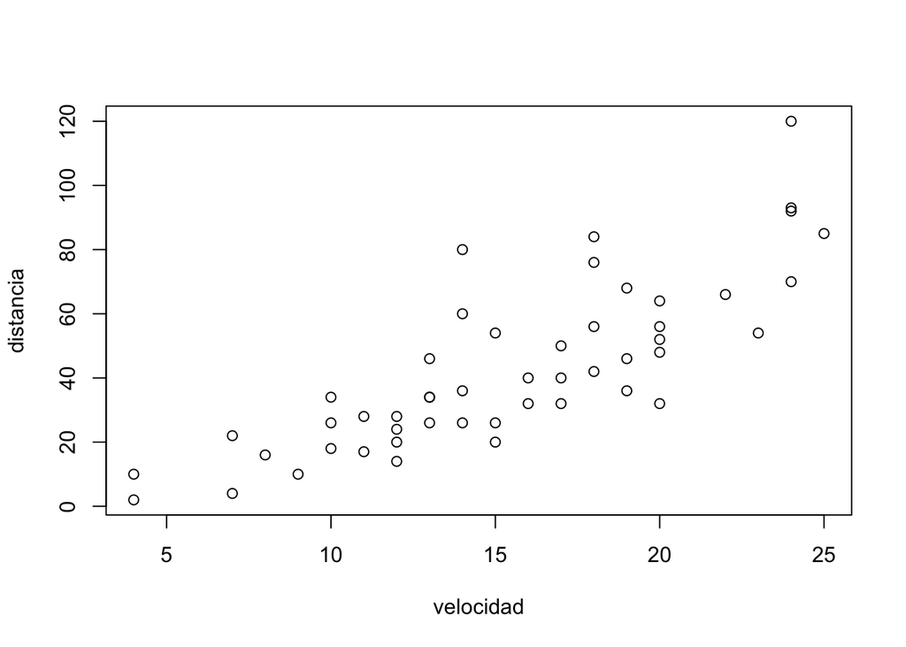

   ```r
   # asignación variables
   velocidad <- cars$speed
   distancia <- cars$dist

   # crear un gráfico de tipo scatter plot (diagrama de dispersión )
   plot(velocidad, distancia)
   ```